# Homework 1

## Applied Machine Learning

### by: Yasshin Lozano

In this assignment you will be getting familiar with Python and practicing some of the concepts discussed in class.

**Make sure to upload both the `.html` and `.ipynb` files to *Canvas*.**

## Problem 1

Consider the following two matrices

$$ A=\left[\begin{array}{cc} 1 & -3\\ 0 & 4\\ 2 & 1 \end{array}\right] $$

and

$$ B=\left[\begin{array}{cccc} 1 & 1 & -1 & 2\\ 2 & 3 & 1 & -2 \end{array}\right] $$

- Use Python to compute the matrix product $AB$.
- Can you compute $BA$ in this case?

**Hint:** import the `numpy` library, define the matrices as shown in class, and use the `numpy.dot` function.

Documentation can be found [here](https://docs.scipy.org/doc/numpy-1.13.0/reference/generated/numpy.dot.html)

## Solutions to Problem 1

Include comments to your solution here

```python
import numpy as np
A = np.array([1,-3,0,4,2,1])
a = A.reshape(3,2)
print('A =\n',a)


B = np.array([1,1,-1,2,2,3,1,-2])
b=B.reshape(2,4)
print('B =\n',b)

np.dot(a,b)
```

```
A =
 [[ 1 -3]
 [ 0  4]
 [ 2  1]]
B =
 [[ 1  1 -1  2]
 [ 2  3  1 -2]]
```

```
array([[-5, -8, -4,  8],
       [ 8, 12,  4, -8],
       [ 4,  5, -1,  2]])
```

```python
np.dot(B*A) #You cannot compute B*A
```

[output not shown]

## Problem 2

Consider the hyperbolic tangent *activation function*

$$ f(x) = \tanh (x) = \frac{e^x - e^{-x}}{e^x + e^{-x}} = \frac{1 - e^{-2x}}{1 + e^{-2x}} $$

Import the `numpy` and `matplotlib` libraries as shown in class, and create a graph of the hyperbolic tangent function with $x$ going from -10 to 10

**Hint:** find out if the hyperbolic tangent is part of `numpy` to avoid having to use the expression with the exponential functions.

## Solutions to Problem 2

Include comments to your solution here

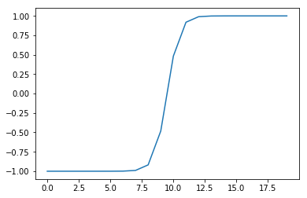

```python
import numpy as np
import matplotlib.pyplot as plt
X = np.linspace(-10,10,20,endpoint=True)
Y= np.tanh(X)
plt.plot(Y)
```

## Problem 3

In this problem, you will be completing the code from chapter 3 of the book, where a *"decision tree algorithm"* is implemented on the `iris` data set. Make sure you can reproduce the results mentioned in the book.

All code used in the book can be found in the official site by Sebastian Raschka: https://github.com/rasbt/python-machine-learning-book-2nd-edition/tree/master/code

### Loading the `iris` data set

Load the `iris` dataset from `scikitlearn`, import the `numpy` library, and define the data matrix `X` and target vector `y`:

```python
from sklearn import datasets
import numpy as np

iris = datasets.load_iris()
X = iris.data[:, [2, 3]]
y = iris.target

print('Class labels:', np.unique(y))
```

```
Class labels: [0 1 2]
```

Splitting data into 70% training and 30% test data:

```python
from sklearn.model_selection import train_test_split

X_train, X_test, y_train, y_test = train_test_split(
    X, y, test_size=0.3, random_state=1, stratify=y)
```

Notice that the vector `y` with a total 150 samples, contains 50 samples for each of the 3 classes. The algorithm will be trained with `y_train` using 35 samples for each class, and tested using `y_test` using 15 observations for each class.

```python
print('Labels counts in y:', np.bincount(y))
print('Labels counts in y_train:', np.bincount(y_train))
print('Labels counts in y_test:', np.bincount(y_test))
```

```
Labels counts in y: [50 50 50]
Labels counts in y_train: [35 35 35]
Labels counts in y_test: [15 15 15]
```

Standardizing the features:

```python
from sklearn.preprocessing import StandardScaler

sc = StandardScaler()
sc.fit(X_train)
X_train_std = sc.transform(X_train)
X_test_std = sc.transform(X_test)
```

We define the function `plot_decision_regions()` to visualize the decision boundaries generated by the classifier

```python
from matplotlib.colors import ListedColormap
import matplotlib.pyplot as plt


def plot_decision_regions(X, y, classifier, test_idx=None, resolution=0.02):

    # setup marker generator and color map
    markers = ('s', 'x', 'o', '^', 'v')
    colors = ('red', 'blue', 'lightgreen', 'gray', 'cyan')
    cmap = ListedColormap(colors[:len(np.unique(y))])

    # plot the decision surface
    x1_min, x1_max = X[:, 0].min() - 1, X[:, 0].max() + 1
    x2_min, x2_max = X[:, 1].min() - 1, X[:, 1].max() + 1
    xx1, xx2 = np.meshgrid(np.arange(x1_min, x1_max, resolution),
                           np.arange(x2_min, x2_max, resolution))
    Z = classifier.predict(np.array([xx1.ravel(), xx2.ravel()]).T)
    Z = Z.reshape(xx1.shape)
    plt.contourf(xx1, xx2, Z, alpha=0.3, cmap=cmap)
    plt.xlim(xx1.min(), xx1.max())
    plt.ylim(xx2.min(), xx2.max())

    for idx, cl in enumerate(np.unique(y)):
        plt.scatter(x=X[y == cl, 0],
                    y=X[y == cl, 1],
                    alpha=0.8,
                    c=colors[idx],
                    marker=markers[idx],
                    label=cl,
                    edgecolor='black')

    # highlight test samples
    if test_idx:
        # plot all samples
        X_test, y_test = X[test_idx, :], y[test_idx]

        plt.scatter(X_test[:, 0],
                    X_test[:, 1],
                    c='',
                    edgecolor='black',
                    alpha=1.0,
                    linewidth=1,
                    marker='o',
                    s=100,
                    label='test set')
```

## Solutions to Problem 3

Use `sklearn.tree` to train a decision tree classifier and the function defined above, `plot_decision_regions()` to recreate the plot in chapter 3. Namely, you need to recreate the following plot:

[figure not shown]

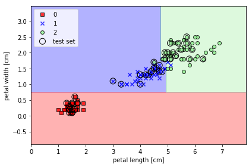

```python
# complete the code below. Check the book and/or the official website
# from sklearn.tree import DecisionTreeClassifier
from sklearn.tree import DecisionTreeClassifier

tree = DecisionTreeClassifier(criterion='gini',
                              max_depth=4,
                              random_state=1)
tree.fit(X_train, y_train)

X_combined = np.vstack((X_train, X_test))
y_combined = np.hstack((y_train, y_test))
plot_decision_regions(X_combined, y_combined,
                      classifier=tree, test_idx=range(105, 150))

plt.xlabel('petal length [cm]')
plt.ylabel('petal width [cm]')
plt.legend(loc='upper left')
plt.tight_layout()
#plt.savefig('images/03_20.png', dpi=300)
plt.show()
```